# act_report

## Data Investigation

After wrangling the three datasets created from the files (`twitter-archive-enhanced.csv`,`image_predictions.tsv`,`tweet_json.txt`), I analyzed the final dataset (`twitter_archive_master.csv`) to get some insights about the tweets by answering the following questions:

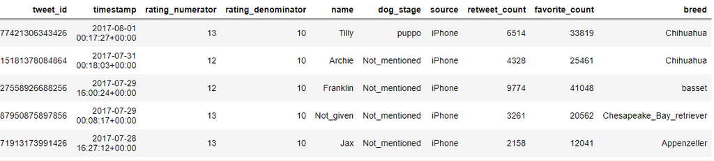

- What is the most popular (liked) breed?
- Which stage has the highest mean rating numerator?
- Show the correlation between the rating_numerator, retweet_count, and favorite_count.
- Visualize the sources usage frequency and find the one with the largest use.

#### Q1: What is the most popular (liked) breed?

The result is **`The most liked breed is: golden_retriever`**. This investigation done by grouping the data by the breed column and using NumPy and Pandas functions to find the `favorite_count` value and indicating the related breed.

### Q2: Which stage has the highest mean rating numerator?

Using `.groupby('dog_stage')` function, I got each stage information including the rating numerator values. Consequently, I found the mean rate for each stage using Pandas `.mean()` and other functions and visualized the result using Matplotlib library.

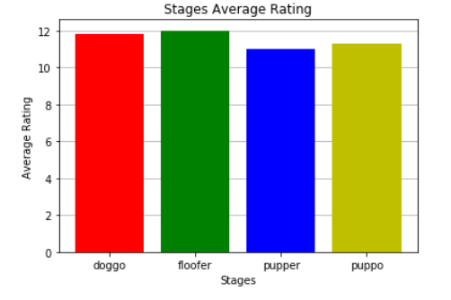

### Q3: Show the correlation between the `rating_numerator`, `retweet_count`, and `favorite_count`?

Here I visualized the correlation matrix between the three variables `rating_numerator`, `retweet_count`, and `favorite_count` using the `.corr()` and `.heatmap()` functions provided by Pandas and Seaborn libraries. The result is shown as follows:

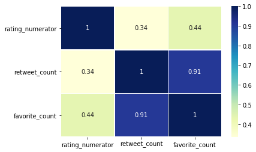

### Q4: Visualize the sources usage frequency and find the one with the largest use

The last question aims to find the most used source to send the tweets on *WeRateDogs* page. By using NumPy and Matplotlib libraries, I got the following bar chart that illustrates how **iPhone** beats the other sources.

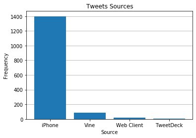

{'iPhone': 1400, 'Vine': 87, 'Web Client': 21, 'TweetDeck': 7}